# Final_temperature-analysis

Allison Davis Connelly & Sophia McKelvey

2026-01-06

# Temperature experiment

**PURPOSE:** Our interest lies in whether sex-baised temperature tolerance exists in 3 livebearing fishes due to dimorphism in size: sailfin mollies (*Poecilia latipinna*), Western mosquitofish (*Gambusia affinis*), and Panuco swordtails (*Xiphophorous nigrensis*). This stems from an observation of males dying when sampling during hot months but females surviving fine.

**MAIN AIMS:** (1) compare female and male thermal tolerance across these three species of livebearing fishes (Family: Poeciliidae) (2) compare thermal tolerance across male morphs within a single livebearing species (*X. nigrensis*)

**HYPOTHESIS:** Preexisting sex differences in size affect resistance to environmental temperature change.

# **Data**

All analyses were conducted using R version 4.4.2

## Load required libraries

Remove the ‘#’ before `install.packages` if it is the first time installing package.

```r
#install.packages("curl")             #v5.2.1
library(curl)
#install.packages("dplyr")            #v1.1.4
library(dplyr)
#install.packages("summarytools")     #v1.1.4
library(summarytools)

#install.packages("gt")               #v0.11.1
library(gt)

#install.packages("tidyr")            #v1.3.1
library(tidyr)

#install.packages("MuMIn)              #v1.48.4
library(MuMIn)

#install.packages("lmerTest")         #v3.1.3
library(lmerTest)
```

```r
#install.packages("sandwich")         #v3.1-1
library(sandwich)

#install.packages("ggplot2")          #v3.5.1
library(ggplot2)

#install.packages("ggpubr")          #v0.6.2
library(ggpubr)
#install.packages("DHARMa")           #v0.4.7
library(DHARMa)
#install.packages("emmeans")          #v1.10.5
library(emmeans)
#install.packages("car")              #v3.1-2
library(car)
#install.packages("patchwork")        #v1.3.2
library(patchwork)

#install.packages("tibble")           #v3.3.1
library(tibble)
```

## Read in data

```r
# OPTION 1: download 'Temp ID-Completed Data.csv' into working directory
rawTempData <- read.csv("Temp ID - Completed Data.csv", header = TRUE, sep = ",", stringsAsFactors = TRUE)
head(rawTempData)
```

```
##        Species Size.cat    Sex   Name CTmax.num CTmin.num CTmax.C CTmin.C
## 1   G. affinis      reg female   Ahoy         9         7  38.630    2.94
## 2 X. nigrensis      reg female    Amy         7         4  36.000   10.56
## 3 P. latipinna      reg female    Amy         4         3  38.375    7.69
## 4 P. latipinna      reg female August         5         5  38.940    7.31
## 5   G. affinis      reg female August         6        NA  37.880      NA
## 6 X. nigrensis      reg female    Ava         2         8  34.940    9.06
##   Size.mm                         file.id.max
## 1    29.7       adavis_ctmax_gambusia_28NOV23
## 2    23.9   mckelvey_ctmax_sword-small_3nov23
## 3    35.2      mckelvey_ctmax_sailfins_6nov23
## 4    31.8     mckelvey_ctmax_sailfins_24oct23
## 5    37.4 mckelvey_ctmax_mosquitofish_17nov23
## 6    23.3   mckelvey_ctmax_sword-large_2nov23
##                          file.id.min
## 1   adavis_ctmin_mosquitofish_1DEC23
## 2 mckelvey_ctmin_sword-small_31oct23
## 3     mckelvey_ctmin_sailfins_9nov23
## 4    mckelvey_ctmin_sailfins_27oct23
## 5                               <NA>
## 6 mckelvey_ctmin_sword-large_30oct23
```

```r
# OPTION 2: load from Github repository
#rawTempData <- curl("https://raw.githubusercontent.com/sophia-m0823/TestRStudio/main/Temp%20ID%20-%20Completed%20Data.csv")
#rawTempData <- read.csv(rawTempData, header = TRUE, sep = ",", stringsAsFactors = TRUE)
#head(rawTempData)



# add common names
rawTempData$Species <- factor(rawTempData$Species,
                        levels = c("X. nigrensis", "P. latipinna", "G. affinis"),
                        labels = c("Swordtail", "Sailfin", "Mosquitofish"))

rawTempData <- na.omit(rawTempData)

#quick view of sample size and trial numbers
species_summary <- rawTempData %>%
  group_by(Species) %>%
  summarise(
    Total_N      = n(),
    Total_Female = sum(Sex == "female", na.rm = TRUE),
    Total_Male   = sum(Sex == "male", na.rm = TRUE),
    CTmax_Trials = n_distinct(file.id.max, na.rm = TRUE),
    CTmin_Trials = n_distinct(file.id.min, na.rm = TRUE)
  ) %>%
  ungroup()

species_summary
```

```
## # A tibble: 3 × 6
##   Species      Total_N Total_Female Total_Male CTmax_Trials CTmin_Trials
##   <fct>          <int>        <int>      <int>        <int>        <int>
## 1 Swordtail         30           15         15            4            4
## 2 Sailfin           40           20         20            5            5
## 3 Mosquitofish      25           12         13            3            3
```

## Summery stats

```r
#remove unnecessary columns
datTot <- rawTempData[,-c(4:6)]

#create long format df to easily summarize later
dat.long <- datTot %>%
  pivot_longer(
    cols = c(CTmax.C, CTmin.C),
    names_to = "Trial",
    values_to = "Value") %>%
  mutate(
    Trial = dplyr::recode(
      Trial,
      "CTmax.C" = "CTmax",
      "CTmin.C" = "CTmin"))

#gather summary stats
summ.stats <- dat.long %>%
  group_by(Species, Trial) %>%
  summarize(
    mean = mean(Value, na.rm = TRUE),
    sd   = sd(Value, na.rm = TRUE),
    min  = min(Value, na.rm = TRUE),
    med  = median(Value, na.rm = TRUE),
    max  = max(Value, na.rm = TRUE),
    .groups = "drop")

#get n for each sex in each species
sex.df <- datTot %>%
  count(Species, Sex) %>%
  tidyr::pivot_wider(
    names_from  = Sex,
    values_from = n,
    values_fill = 0)

#final table
summ.stats.all <- summ.stats %>%
  left_join(sex.df, by = "Species") %>%
  mutate(
    mean_sd = sprintf("%.2f (%.2f)", mean, sd))

summ.stats.all
```

```
## # A tibble: 6 × 10
##   Species      Trial  mean    sd   min   med   max female  male mean_sd
##   <fct>        <chr> <dbl> <dbl> <dbl> <dbl> <dbl>  <int> <int> <chr>
## 1 Swordtail    CTmax 35.3  1.02  32.1  35.6  36.2      15    15 35.27 (1.02)
## 2 Swordtail    CTmin  9.86 0.664  8.56  9.91 11.1      15    15 9.86 (0.66)
## 3 Sailfin      CTmax 38.5  0.771 36.8  38.4  39.8      20    20 38.48 (0.77)
## 4 Sailfin      CTmin  6.70 1.41   3.56  6.97  9.25     20    20 6.70 (1.41)
## 5 Mosquitofish CTmax 37.7  1.31  34.6  38.1  39.2      12    13 37.68 (1.31)
## 6 Mosquitofish CTmin  4.77 1.72   2.06  4.19  8        12    13 4.77 (1.72)
```

## Size stats

When separated by sex and species, we see that there appears to be an overlap between small swordtail males and swordtail females (although they differ from large swordtail males), overlap between males and females in sailfins, and very little overlap among males and females in mosquitofish. This is confirmed through wilcoxon/kruskal-wallis tests: sailfin males and females show no significant difference in length with a small effect size (although wide CI may indicate uncertainty in magnitude and direction of any small difference), male and female mosquitofish show a significant difference in size with a large effect size indicating females are almost always larger than males, and swordtail sex categories (female, large male, small male) show a significant difference in length (as expected since male classes are separated by size), with a significant pairwise comparison among all groups and a large effect size indicating small males < females < large males.

Sexual dimorphism in length was evident for mosquitofish and among sex/morph groups in swordtails (although direction of size difference varied among morphs). Evidence for sexual dimorphism in our sailfin was inconclusive, with negligible effect sizes but a wide confidence interval.

Overall collinearity is low for CTmax and CTmin trials, but separation by species shows low collinearity of sex and size for sailfins in both trial types and high collinearity of sex and size for mosquitofish in both trial types (makes sense since males and females showed little overlap in size for mosquitofish). Collinearity is high for size and sex/morph class in swordtails, which again makes sense because male classes are determined by size. Will need to interpret model results with this in mind (can’t really detect a sex-only difference after accounting for similar sizes in mosquitofish and swordtail because there are no similar sizes in swordtails).

**Table and plot**

```r
# Average lengths by species & sex

#gather summary stats
sizes <- datTot %>%
  group_by(Species, Sex) %>%
  summarise(
    avg.len = mean(Size.mm),
    st.dev = sd(Size.mm),
    .groups = "drop")

#final table
 sizes.fmt <- sizes %>%
   mutate(
    size.display = sprintf("%.1f (%.2f)", avg.len, st.dev)) %>%
  select(Species, Sex, size.display) %>%
  pivot_wider(
    names_from = Sex,
    values_from = size.display)

sizes.fmt
```

```
## # A tibble: 3 × 3
##   Species      female      male
##   <fct>        <chr>       <chr>
## 1 Swordtail    23.1 (1.54) 26.5 (7.72)
## 2 Sailfin      33.1 (3.89) 33.7 (2.73)
## 3 Mosquitofish 29.5 (2.89) 21.5 (1.65)
```

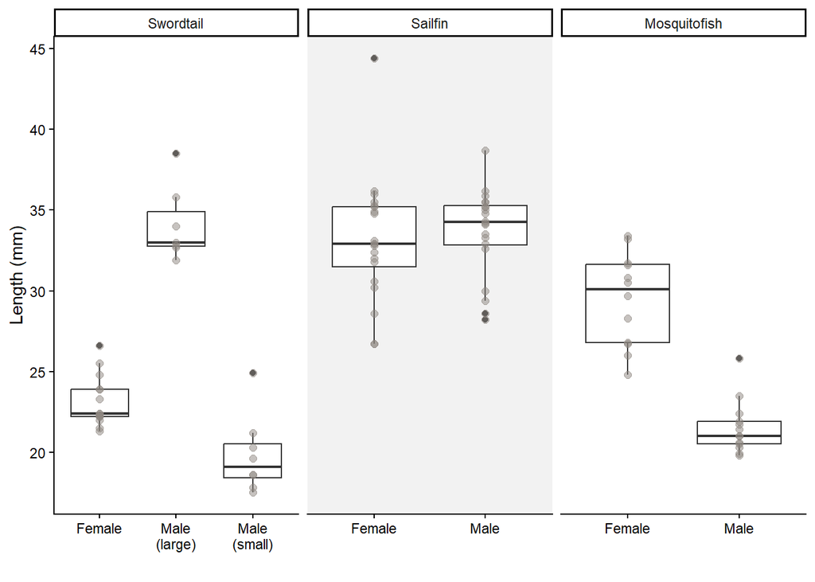

```r
### boxplot

#create more intuitive sex categories for swordtails
dat.plot <- datTot %>%
  mutate(
    Sex.plot = case_when(
      Species == "Swordtail" & Sex == "male" & Size.cat == "small" ~ "Male (small)",
      Species == "Swordtail" & Sex == "male" & Size.cat == "large" ~ "Male (large)",
      Sex == "male"                                             ~ "Male",
      Sex == "female"                                           ~ "Female"))

#final plot
ggplot(dat.plot, aes(x = Sex.plot, y = Size.mm)) +
  geom_rect(
    data = subset(datTot, Species == "Sailfin"),
    inherit.aes = FALSE,
    xmin = -Inf, xmax = Inf,
    ymin = -Inf, ymax = Inf,
    fill = "grey95") +
  geom_boxplot(linewidth= 0.4) +
  geom_point(color= "#8D8680", size=2, alpha=0.5) +
  facet_wrap(~ Species, scales = "free_x") +
  scale_x_discrete(
  labels = function(x) {
    ifelse(x %in% c("Male (small)", "Male (large)"),
           gsub(" ", "\n", x),
           x)}) +
  theme_classic() +
  xlab("") +
  ylab("Length (mm)")
```

```r
# Average lengths by sex

#gather summary stats
sizes2 <- datTot %>%
  group_by(Sex) %>%
  summarise(
    avg.len = mean(Size.mm),
    st.dev = sd(Size.mm),
    .groups = "drop")

#final table
 sizes.fmt2 <- sizes2 %>%
   mutate(
    size.display = sprintf("%.1f (%.2f)", avg.len, st.dev)) %>%
  select(Sex, size.display) %>%
  pivot_wider(
    names_from = Sex,
    values_from = size.display)

sizes.fmt2
```

```
## # A tibble: 1 × 2
##   female      male
##   <chr>       <chr>
## 1 29.0 (5.28) 28.1 (6.88)
```

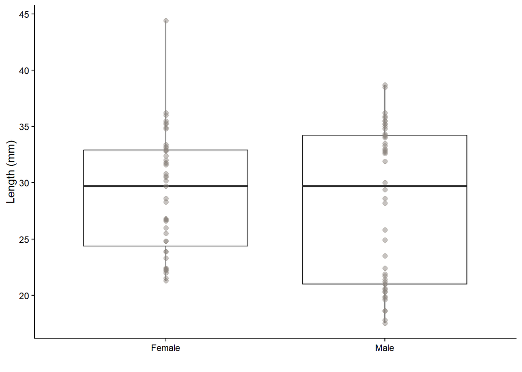

```r
### boxplot

#final plot
ggplot(datTot, aes(x = Sex, y = Size.mm)) +
  geom_boxplot() +
  geom_point(color= "#8D8680", size=2, alpha=0.5) +
  theme_classic() +
  xlab("") +
  ylab("Length (mm)") +
  scale_x_discrete(labels=c('Female', 'Male'))
```

**Length comparisons and effect size**

```r
#separate male classes in swordtails
size.data <- datTot %>%
  mutate(
    SizeGroup = case_when(
      Species == "Swordtail" & Sex == "female" ~ "Female",
      Species == "Swordtail" & Sex == "male" & Size.cat == "large" ~ "Large male",
      Species == "Swordtail" & Sex == "male" & Size.cat == "small" ~ "Small male",
      Species != "Swordtail" ~ as.character(Sex),
      TRUE ~ NA_character_))


#normality check by sex and species
normal <- size.data %>%
  group_by(Species, SizeGroup) %>%
summarize(statistic =shapiro.test(Size.mm)$statistic,
          p.value = shapiro.test(Size.mm)$p.value)
```

```
## `summarise()` has regrouped the output.
## ℹ Summaries were computed grouped by Species and SizeGroup.
## ℹ Output is grouped by Species.
## ℹ Use `summarise(.groups = "drop_last")` to silence this message.
## ℹ Use `summarise(.by = c(Species, SizeGroup))` for per-operation grouping
##   (`?dplyr::dplyr_by`) instead.
```

```r
normal #all normal except female swordtail and male mosquitofish
```

```
## # A tibble: 7 × 4
## # Groups:   Species [3]
##   Species      SizeGroup  statistic p.value
##   <fct>        <chr>          <dbl>   <dbl>
## 1 Swordtail    Female         0.878  0.0446
## 2 Swordtail    Large male     0.853  0.131
## 3 Swordtail    Small male     0.863  0.129
## 4 Sailfin      female         0.909  0.0606
## 5 Sailfin      male           0.912  0.0709
## 6 Mosquitofish female         0.941  0.512
## 7 Mosquitofish male           0.859  0.0374
```

```r
#non-parametric test for size difference by species
size.test <- datTot %>%
  filter(Species != "Swordtail") %>%
  group_by(Species) %>%
  summarize(stat = wilcox.test(Size.mm ~ Sex)$statistic,
            p_value = wilcox.test(Size.mm~Sex)$p.value)

size.test #not significant for sailfin, but significant for mosquitofish
```

```
## # A tibble: 2 × 3
##   Species       stat     p_value
##   <fct>        <dbl>       <dbl>
## 1 Sailfin       168. 0.402
## 2 Mosquitofish  155  0.000000769
```

```r
sw.size.test <- size.data %>%
  filter(Species == "Swordtail") %>%
  summarize(stat = kruskal.test(Size.mm ~ SizeGroup)$statistic,
            p_value = kruskal.test(Size.mm ~ SizeGroup)$p.value)

sw.size.test #significant difference among sex categories; makes sense since the male classes are determined by size
```

```
##      stat      p_value
## 1 21.0672 2.662663e-05
```

```r
pw.dat <- size.data %>%
  filter(Species == "Swordtail")
pw.test <- pairwise.wilcox.test( pw.dat$Size.mm, pw.dat$SizeGroup, p.adjust.method = "BH")

pw.test #all pairs significantly different
```

```
##
##  Pairwise comparisons using Wilcoxon rank sum exact test
##
## data:  pw.dat$Size.mm and pw.dat$SizeGroup
##
##            Female  Large male
## Large male 3.5e-05 -
## Small male 0.00128 0.00047
##
## P value adjustment method: BH
```

```r
#testing effect size
eff.size.tbl <- datTot %>%
  filter(Species != "Swordtail") %>%
  group_by(Species) %>%
  summarise({
    cd <- effsize::cliff.delta(Size.mm ~ Sex)
    tibble(
      delta= cd$estimate,
    CI_low = cd$conf.int[1],
    CI_high = cd$conf.int[2])})

eff.size.tbl #sailfins with small effect size (-0.16) but wide CI (-0.49, 0.23) so there is uncertainty in the magnitude and direction of sexual size dimorphism. mosquitofish on the other hand show a large effect size with females being larger than males (0.99, CI 0.92, 0.998).
```

```
## # A tibble: 2 × 4
##   Species       delta CI_low CI_high
##   <fct>         <dbl>  <dbl>   <dbl>
## 1 Sailfin      -0.158 -0.490   0.215
## 2 Mosquitofish  0.987  0.923   0.998
```

```r
comparison <- list(
  c("Female", "Small male"),
  c("Female", "Large male"),
  c("Small male", "Large male"))

sw.eff.size <- bind_rows(lapply(comparison, function (g) {
  x <- pw.dat$Size.mm[pw.dat$SizeGroup == g[1]]
  y <- pw.dat$Size.mm[pw.dat$SizeGroup == g[2]]
  cd <- effsize::cliff.delta(x,y)

  tibble(
    group1 = g[1],
    group2 = g[2],
    delta = unname(cd$estimate),
    CI_low = cd$conf.int[1],
    CI_high = cd$conf.int[2])  }))
sw.eff.size #large size effects for all three combos; size ranking as follows: small males -> females -> large males
```

```
## # A tibble: 3 × 5
##   group1     group2      delta  CI_low CI_high
##   <chr>      <chr>       <dbl>   <dbl>   <dbl>
## 1 Female     Small male  0.783  0.0598   0.967
## 2 Female     Large male -1     -1       -0.974
## 3 Small male Large male -1     -1       -0.943
```

**Collinearity**

```r
library(lme4)
### CTmax ###
model1 <- lmer(CTmax.C ~ Species + Sex + Size.mm + (1|file.id.max), data = datTot, REML = FALSE)

vif(model1) #shows low levels of collinearity for all effects
```

```
##             GVIF Df GVIF^(1/(2*Df))
## Species 1.747771  2        1.149797
## Sex     1.008791  1        1.004386
## Size.mm 1.757088  1        1.325552
```

```r
vif.spp <- datTot %>%
  filter(Species != "Swordtail") %>% #since there are distinct size classes here
  group_by(Species) %>%
  group_modify( ~ {
    model <- lmer(CTmax.C ~ Sex + Size.mm + (1|file.id.max), data = .x, REML = FALSE)
    v <- vif(model)

    tibble(
      Predictor = names(v),
      VIF = as.numeric(v),
      Singular = isSingular(model)) }) %>%
  ungroup()

vif.spp #low collinearity for sailfins, but high for mosquitofish; makes sense since we saw large sexual size dimorphism in this species
```

```
## # A tibble: 4 × 4
##   Species      Predictor   VIF Singular
##   <fct>        <chr>     <dbl> <lgl>
## 1 Sailfin      Sex        1.01 FALSE
## 2 Sailfin      Size.mm    1.01 FALSE
## 3 Mosquitofish Sex        4.30 FALSE
## 4 Mosquitofish Size.mm    4.30 FALSE
```

```r
vif.sw <- size.data %>%
  filter(Species == "Swordtail") %>%
  group_modify( ~ {
    model <- lmer(CTmax.C ~ SizeGroup + Size.mm + (1|file.id.max), data = .x, REML = FALSE)
    v <- vif(model)

    tibble::rownames_to_column(
      as.data.frame(v),
      var = "Predictor") %>%
      mutate(Singular = isSingular(model)) }) %>%
  ungroup()
```

```
## boundary (singular) fit: see help('isSingular')
```

```r
vif.sw #adjusted GVIF for size group and size.mm indicate strong collinearity among size and sex/morph class; makese sense since the males are separated by size, but will need to keep this in mind when interpreting results. singular fit shows no variation in trial runs
```

```
##   Predictor     GVIF Df GVIF^(1/(2*Df)) Singular
## 1 SizeGroup 9.032758  2        1.733625     TRUE
## 2   Size.mm 9.032758  1        3.005455     TRUE
```

```r
### CTmin ###
model1 <- lmer(CTmin.C ~ Species + Sex + Size.mm + (1|file.id.min), data = datTot, REML = FALSE)

vif(model1) #shows low levels of collinearity for all effects
```

```
##             GVIF Df GVIF^(1/(2*Df))
## Species 1.031358  2        1.007749
## Sex     1.010794  1        1.005383
## Size.mm 1.042184  1        1.020874
```

```r
vif.spp <- datTot %>%
  filter(Species != "Swordtail") %>% #since there are distinct size classes here
  group_by(Species) %>%
  group_modify( ~ {
    model <- lmer(CTmin.C ~ Sex + Size.mm + (1|file.id.min), data = .x, REML = FALSE)
    v <- vif(model)

    tibble(
      Predictor = names(v),
      VIF = as.numeric(v),
      Singular = isSingular(model)) }) %>%
  ungroup()

vif.spp #low collinearity for sailfins, but high for mosquitofish; makes sense since we saw large sexual size dimorphism in this species
```

```
## # A tibble: 4 × 4
##   Species      Predictor   VIF Singular
##   <fct>        <chr>     <dbl> <lgl>
## 1 Sailfin      Sex        1.01 FALSE
## 2 Sailfin      Size.mm    1.01 FALSE
## 3 Mosquitofish Sex        4.44 FALSE
## 4 Mosquitofish Size.mm    4.44 FALSE
```

```r
vif.sw <- size.data %>%
  filter(Species == "Swordtail") %>%
  group_modify( ~ {
    model <- lmer(CTmin.C ~ SizeGroup + Size.mm + (1|file.id.min), data = .x, REML = FALSE)
    v <- vif(model)

    tibble::rownames_to_column(
      as.data.frame(v),
      var = "Predictor") %>%
      mutate(Singular = isSingular(model)) }) %>%
  ungroup()
vif.sw #adjusted GVIF for size group and size.mm indicate strong collinearity among size and sex/morph class; makese sense since the males are separated by size, but will need to keep this in mind when interpreting results.
```

```
##   Predictor     GVIF Df GVIF^(1/(2*Df)) Singular
## 1 SizeGroup 5.893356  2        1.558083    FALSE
## 2   Size.mm 5.893356  1        2.427624    FALSE
```

```r
#all CTmin trials without singular fit, file.id required for models
```

# **Analysis**

## **CTmax**

### Model Selection

Here, we will run linear mixed effects models with CTmax as our dependent variable, and sex, species, and size (plus their interaction) as our independent variables. We will select our final model based on ΔAIC scores from the ‘MuMln’ package.

**Results:** The model containing just species as a dependent variable was the most supported in our model selection (ΔAICc=0.0; weight=0.511). Adding size (mod1b) or sex (mod1c) or both (mod1d) did not improve fit, but as they are characters of interest will will still examine the coefficients for comparison.

```r
# All models
mod1 <- lmer(CTmax.C ~ Species + (1|file.id.max), data = datTot, REML = FALSE)
      #does CTmax differ among spp?
mod1b <- lmer(CTmax.C ~ Species + Size.mm + (1|file.id.max), data = datTot, REML = FALSE)
      #is body size associated with CTmax after accounting for species?
mod1c <- lmer(CTmax.C ~ Species + Sex + (1|file.id.max), data = datTot, REML = FALSE)
      #is sex associated with CTmax after accounting for species?
mod1d <- lmer(CTmax.C ~ Species + Sex + Size.mm + (1|file.id.max), data = datTot, REML = FALSE)       #are sex and size independently associated with CTmax? *Remember collinearity
mod1e <- lmer(CTmax.C ~ Species + Sex * Size.mm + (1|file.id.max), data = datTot, REML = FALSE)
      #does the relationship between size and CTmax differ between males and females?
mod1f <- lmer(CTmax.C ~ Species * Sex + Size.mm + (1|file.id.max), data = datTot, REML = FALSE)
      #do sex-associated differences in CTmax vary among species, after accounting for size?
mod1g <- lmer(CTmax.C ~ Species *Size.mm + Sex + (1|file.id.max), data = datTot, REML = FALSE)
      #does body size and CTmax vary among species after accounting for sex?

# Model selection
model.sel(mod1, mod1b, mod1c, mod1d, mod1e, mod1f, mod1g)
```

```
## Model selection table
##       (Int) Spc     Siz.mm Sex Sex:Siz.mm Sex:Spc Siz.mm:Spc df   logLik  AICc
## mod1  35.26   +                                               5 -134.528 279.7
## mod1c 35.19   +              +                                6 -134.257 281.5
## mod1b 35.32   + -0.0023560                                    6 -134.523 282.0
## mod1d 35.21   + -0.0007999   +                                7 -134.256 283.8
## mod1e 35.81   + -0.0234500   +          +                     8 -133.889 285.5
## mod1g 34.81   +  0.0160300   +                             +  9 -133.983 288.1
## mod1f 35.22   + -0.0021750   +                  +             9 -134.243 288.6
##       delta weight
## mod1   0.00  0.511
## mod1c  1.74  0.214
## mod1b  2.27  0.164
## mod1d  4.07  0.067
## mod1e  5.72  0.029
## mod1g  8.35  0.008
## mod1f  8.87  0.006
## Models ranked by AICc(x)
## Random terms (all models):
##   1 | file.id.max
```

```r
  ### Mod1 (species only effect) is the most supported model (ΔAICc=0; weight=0.511)
  ### Adding size (mod1b) or sex (mod1c) or both (mod1d) did not improve fit, but as they are characters of interest will will still examine the coefficients for comparison
  ### Interactive effects (mod1e-g) showed very weak support, so allowing sex or size to vary did not improve model fit enough to justify the additional parameters; also possible that it is unstable to add additional parameters given our low sample size
```

### Residual checks

Here, we will check if the model residuals are normal and homoscedastic using the ‘DHARMa’ package.

**Results:** All models showed no outlier deviation or heteroscedasticity.

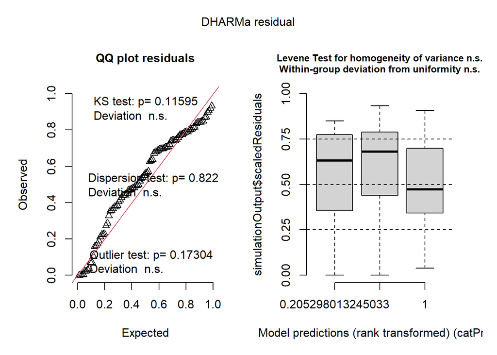

```r
# Species only model
simulationOutput <- simulateResiduals(mod1, n = 1000)

plot(simulationOutput)
```

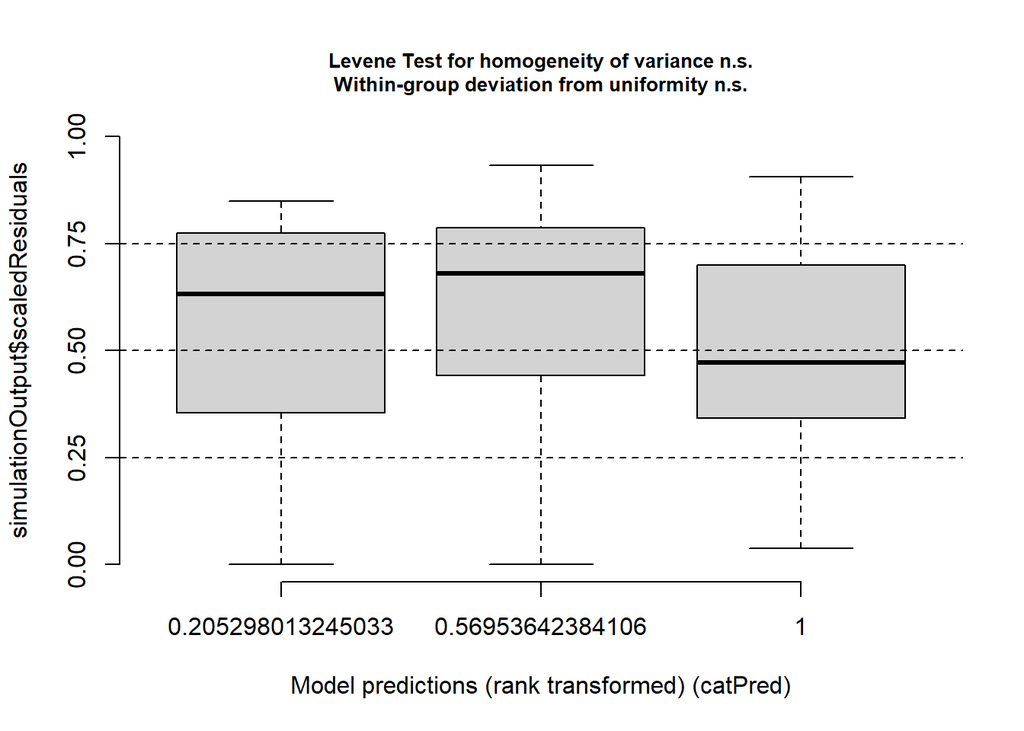

```r
plotResiduals(simulationOutput)
```

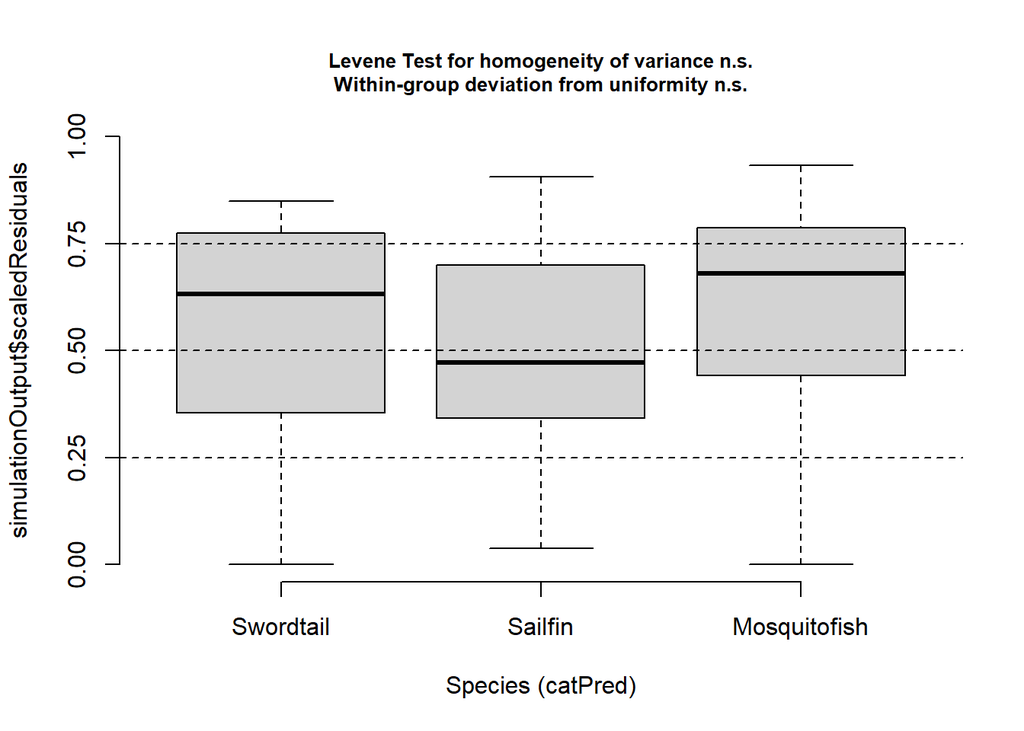

```r
plotResiduals(simulationOutput, form = rawTempData$Species)
```

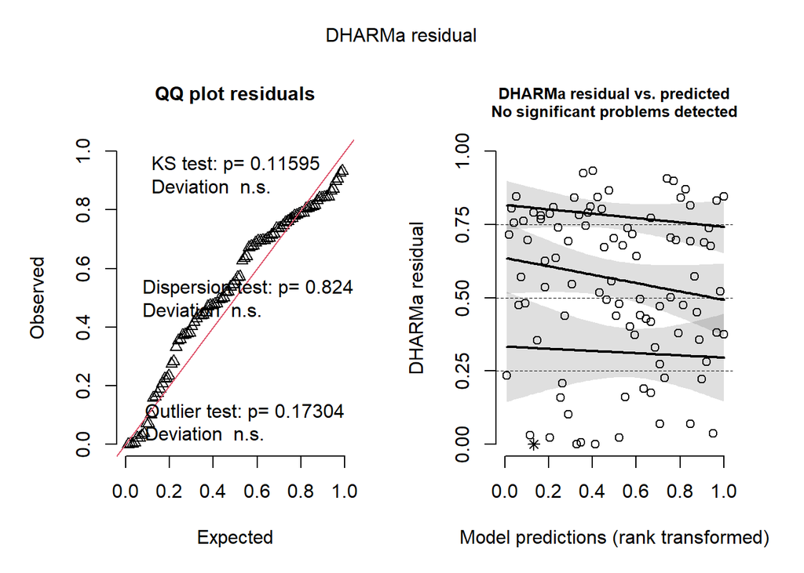

```r
  ### All good!


# Species and size model
simulationOutput2 <- simulateResiduals(mod1b, n = 1000)

plot(simulationOutput2)
```

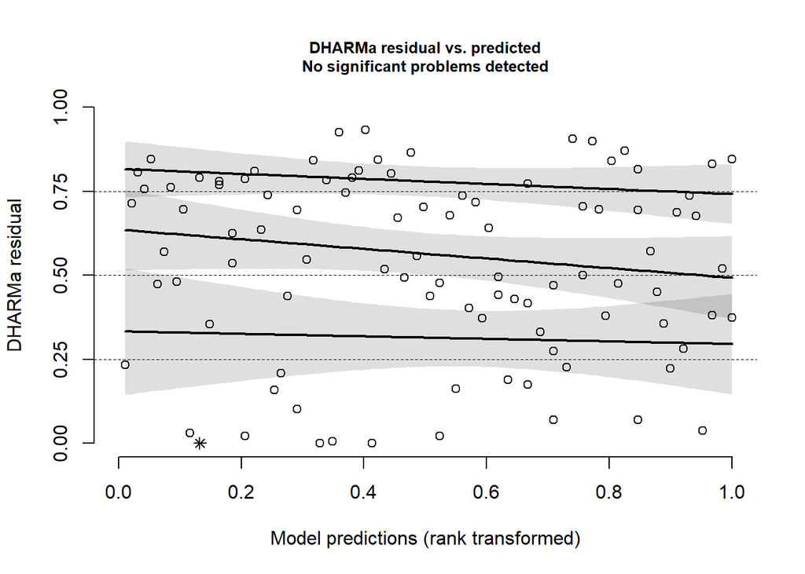

```r
plotResiduals(simulationOutput2)
```

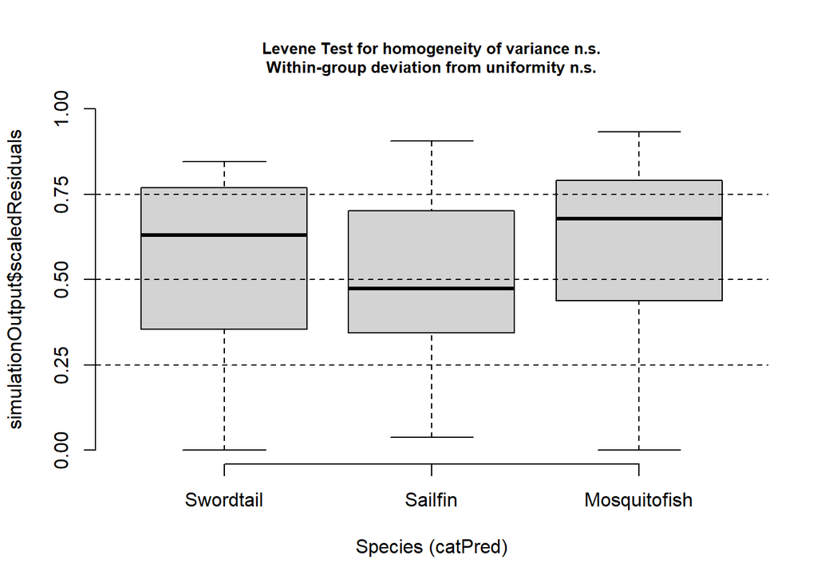

```r
plotResiduals(simulationOutput2, form = rawTempData$Species)
```

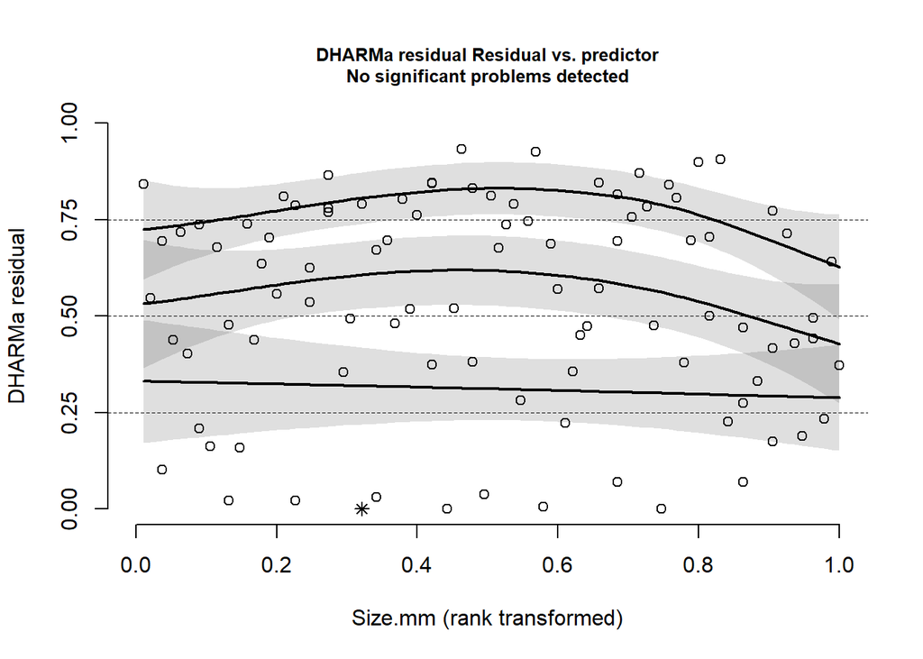

```r
plotResiduals(simulationOutput2, form = rawTempData$Size.mm)
```

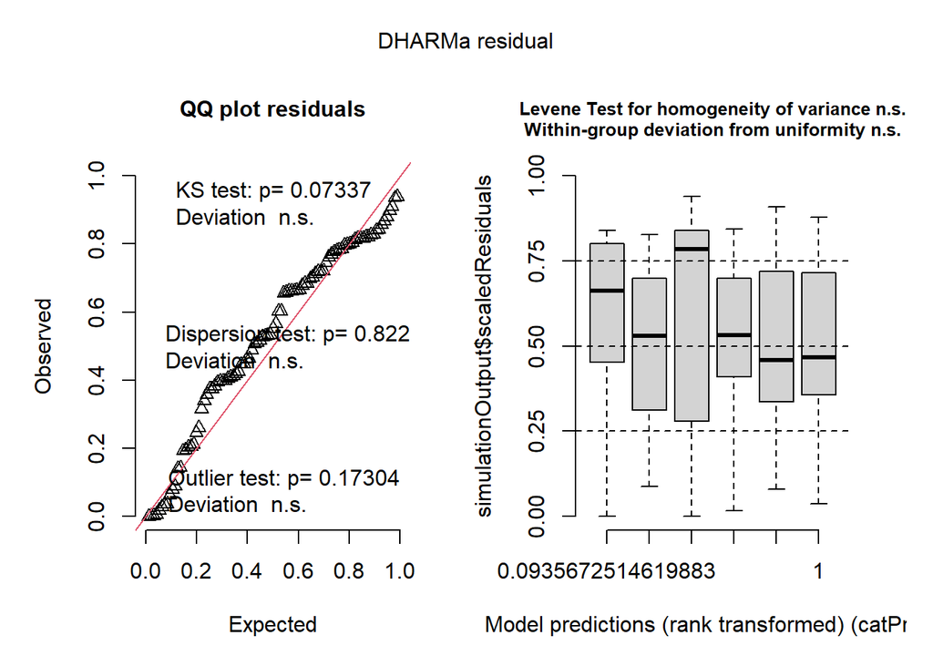

```r
  ### All good!

# Species and sex model
simulationOutput3 <- simulateResiduals(mod1c, n = 1000)

plot(simulationOutput3)
```

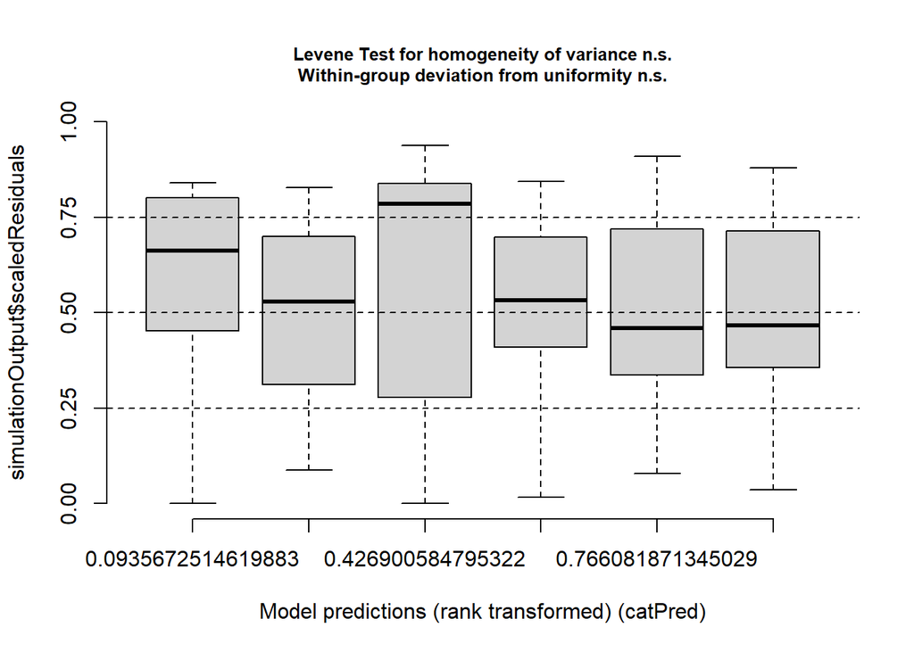

```r
plotResiduals(simulationOutput3)
```

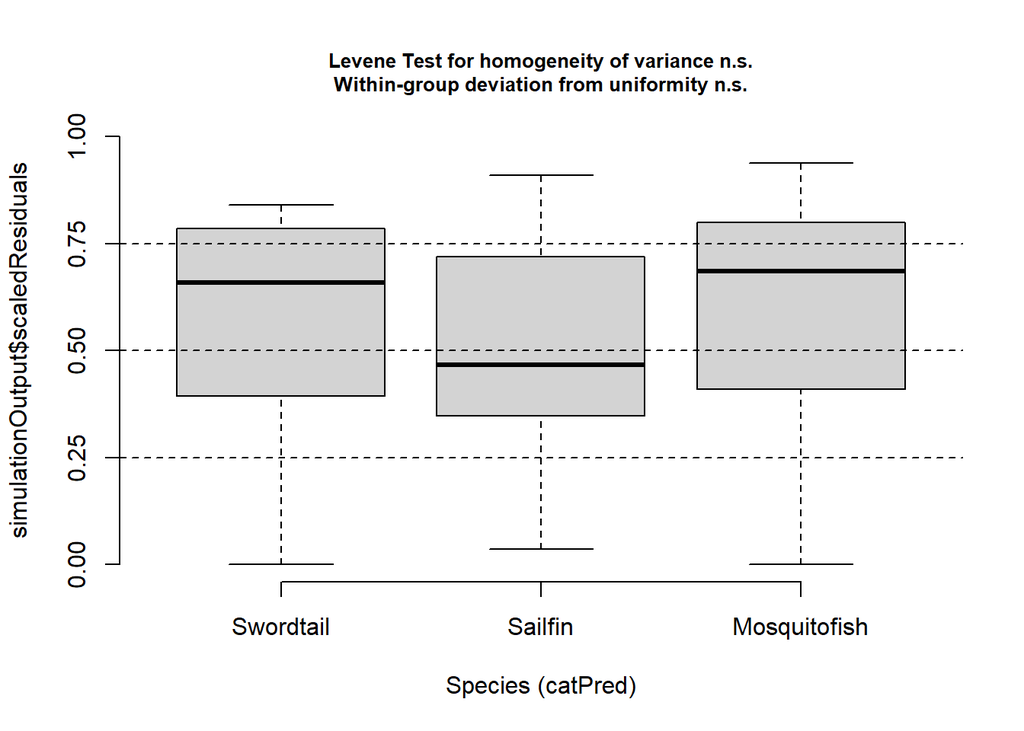

```r
plotResiduals(simulationOutput3, form = rawTempData$Species)
```

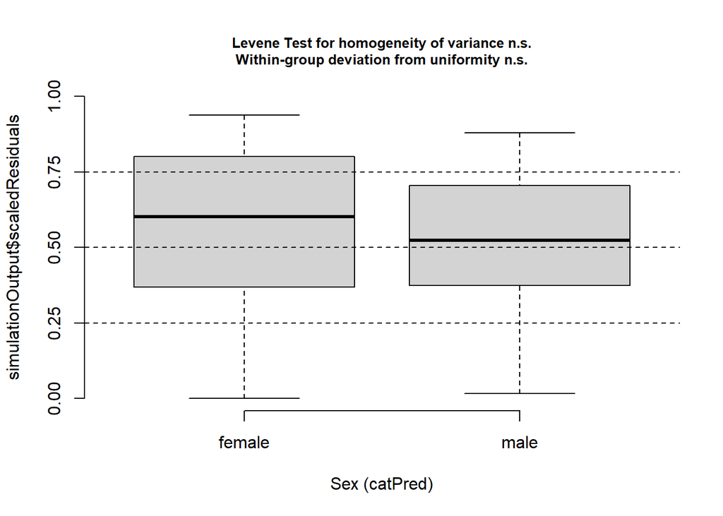

```r
plotResiduals(simulationOutput3, form = rawTempData$Sex)
```

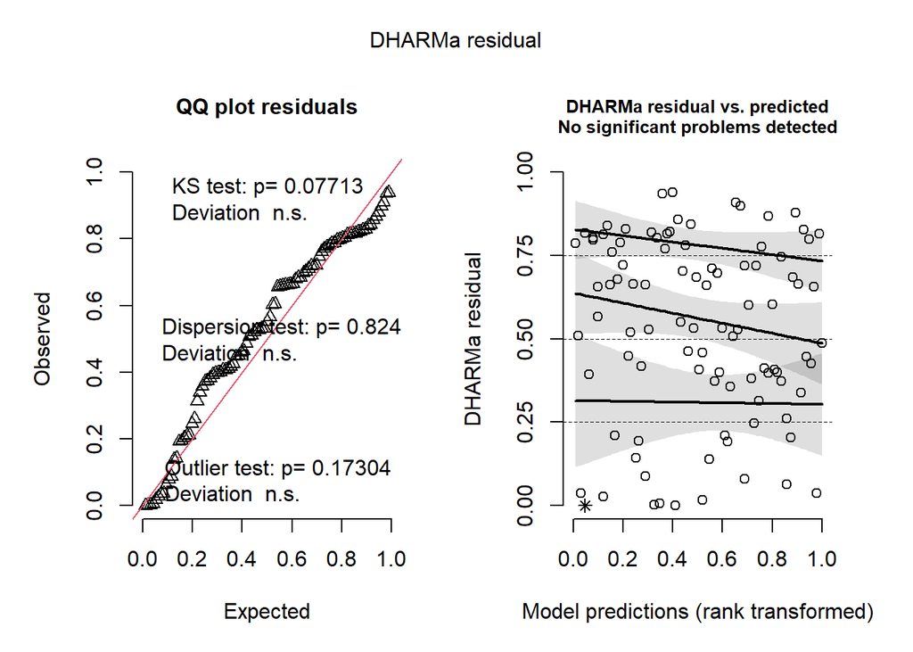

```r
  ### All good!

# Species and sex and size model
simulationOutput4 <- simulateResiduals(mod1d, n = 1000)

plot(simulationOutput4)
```

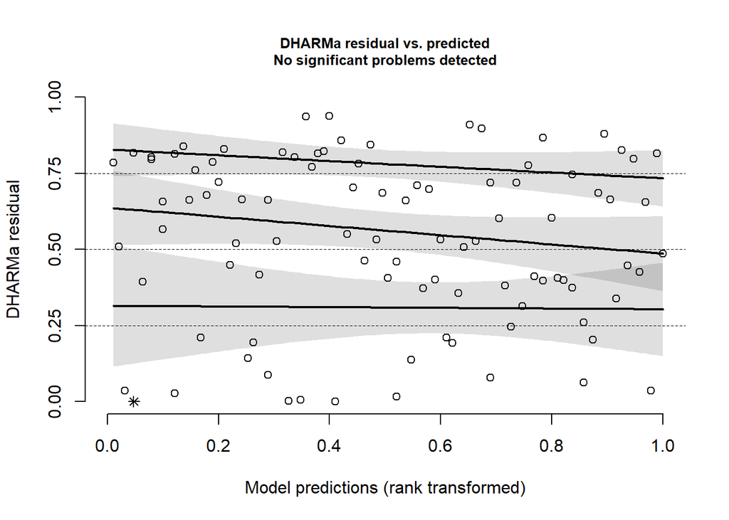

```r
plotResiduals(simulationOutput4)
```

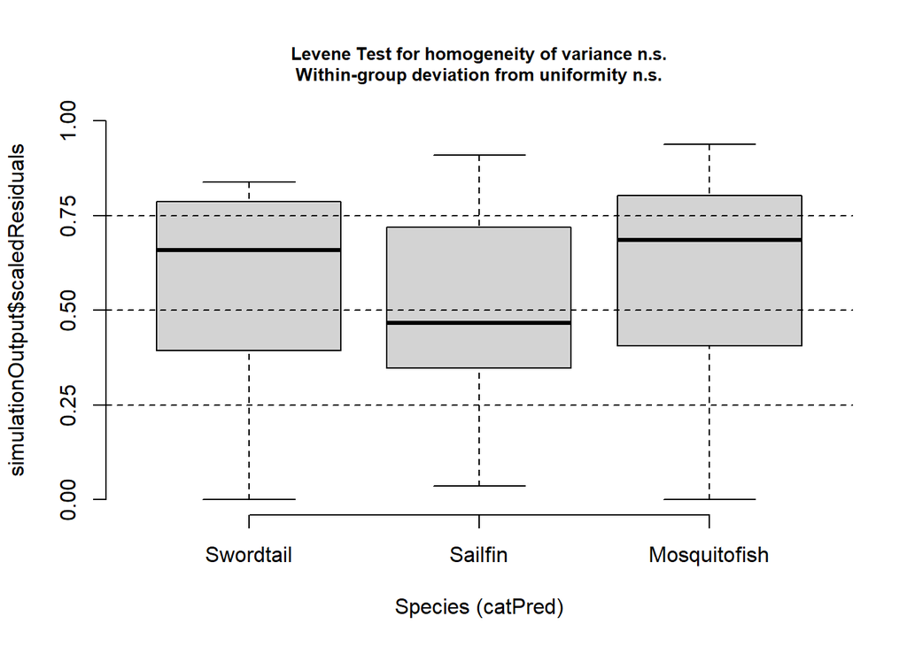

```r
plotResiduals(simulationOutput4, form = rawTempData$Species)
```

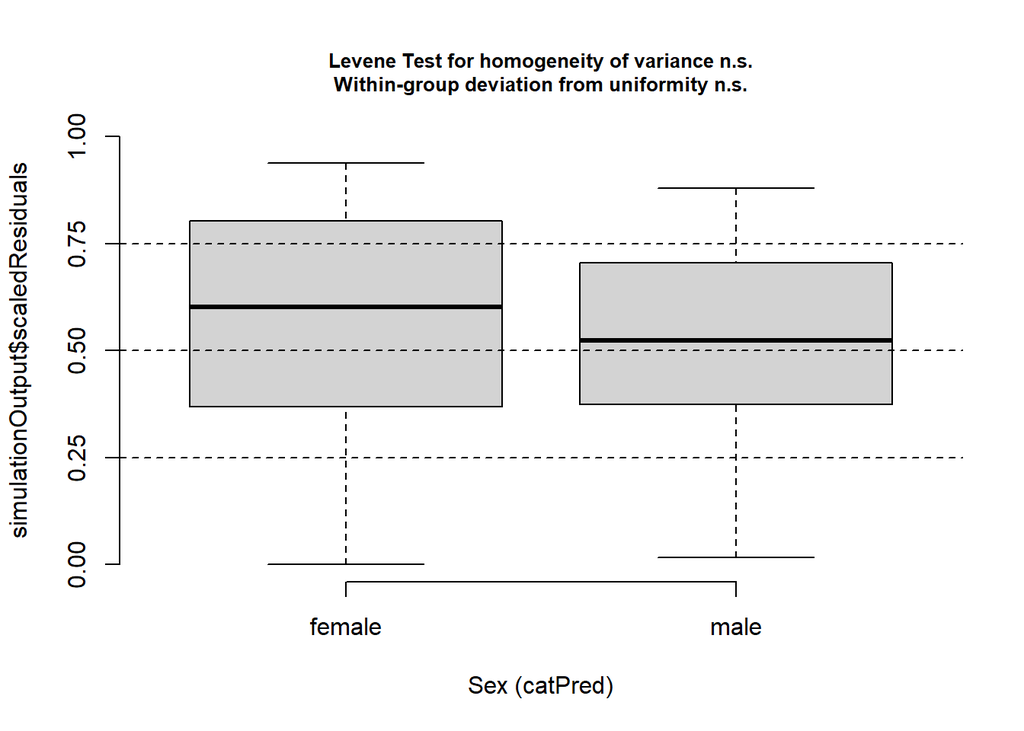

```r
plotResiduals(simulationOutput4, form = rawTempData$Sex)
```

```
## qu = 0.75, log(sigma) = -2.812892 : outer Newton did not converge fully.
```

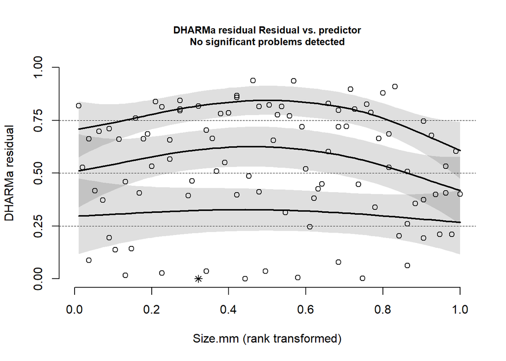

```r
plotResiduals(simulationOutput4, form = rawTempData$Size.mm)
```

```r
  ### All good!
```

### Model Summary

We will determine the overall effect of species (anova from ‘lmerTest’ package; using Satterthwaite approximation due to small sample size of random effect), and calculate the estimated marginal means and a pairwise species comparison (emmeans package). Model summaries will provide us with the effect of sex and size on the model.

```r
# SPECIES ONLY MODEL
 ## Overall species effect
anova(mod1, type = 2, ddf = "Satterthwaite") #significant (p<0.001)
```

```
## Type II Analysis of Variance Table with Satterthwaite's method
##         Sum Sq Mean Sq NumDF  DenDF F value    Pr(>F)
## Species 154.35  77.174     2 12.312   79.35 9.238e-08 ***
## ---
## Signif. codes:  0 '***' 0.001 '**' 0.01 '*' 0.05 '.' 0.1 ' ' 1
```

```r
 ## EMM & Pairwise comparisons

PW.sp.max <- emmeans(mod1, "Species", lmer.df = "satterthwaite")
summary(PW.sp.max) #EMM
```

```
##  Species      emmean    SE   df lower.CL upper.CL
##  Swordtail      35.3 0.196 13.4     34.8     35.7
##  Sailfin        38.5 0.170 12.3     38.1     38.8
##  Mosquitofish   37.7 0.216 11.4     37.2     38.1
##
## Degrees-of-freedom method: satterthwaite
## Confidence level used: 0.95
```

```r
pairs(PW.sp.max, adjust = "holm") #Pairwise results
```

```
##  contrast                 estimate    SE   df t.ratio p.value
##  Swordtail - Sailfin        -3.215 0.260 12.9 -12.387 <0.0001
##  Swordtail - Mosquitofish   -2.407 0.292 12.3  -8.251 <0.0001
##  Sailfin - Mosquitofish      0.808 0.275 11.7   2.936  0.0127
##
## Degrees-of-freedom method: satterthwaite
## P value adjustment: holm method for 3 tests
```

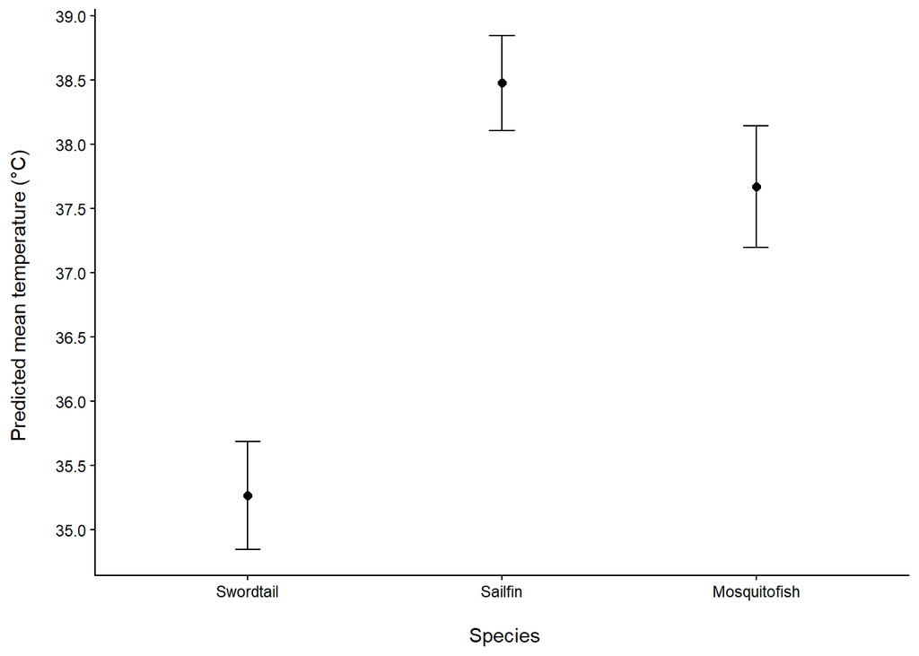

```r
 ## Plotting EMM

PW.df <- as.data.frame(confint(PW.sp.max))

ggplot(PW.df, aes(x=Species, y=emmean)) +
  geom_point(size=2) +
  geom_errorbar(aes(ymin=lower.CL, ymax=upper.CL), width=0.1) +
  scale_y_continuous(breaks = scales::pretty_breaks(n = 10)) +
  ylab("Predicted mean temperature (°C) \n") +
  xlab("\n Species") +
  theme_classic()
```

```r
# SPECIES & SIZE MODEL

summary(mod1b)
```

```
## Linear mixed model fit by maximum likelihood . t-tests use Satterthwaite's
##   method [lmerModLmerTest]
## Formula: CTmax.C ~ Species + Size.mm + (1 | file.id.max)
##    Data: datTot
##
##       AIC       BIC    logLik -2*log(L)  df.resid
##     281.0     296.4    -134.5     269.0        89
##
## Scaled residuals:
##     Min      1Q  Median      3Q     Max
## -3.1371 -0.3325  0.1306  0.7328  1.5736
##
## Random effects:
##  Groups      Name        Variance Std.Dev.
##  file.id.max (Intercept) 0.02307  0.1519
##  Residual                0.97283  0.9863
## Number of obs: 95, groups:  file.id.max, 12
##
## Fixed effects:
##                      Estimate Std. Error        df t value Pr(>|t|)
## (Intercept)         35.322528   0.604448 76.691246  58.438  < 2e-16 ***
## SpeciesSailfin       3.235545   0.326007 25.818464   9.925 2.67e-10 ***
## SpeciesMosquitofish  2.408478   0.291587 12.295713   8.260 2.30e-06 ***
## Size.mm             -0.002356   0.023041 90.632099  -0.102    0.919
## ---
## Signif. codes:  0 '***' 0.001 '**' 0.01 '*' 0.05 '.' 0.1 ' ' 1
##
## Correlation of Fixed Effects:
##             (Intr) SpcsSl SpcsMs
## SpeciesSlfn  0.380
## SpcsMsqtfsh -0.179  0.427
## Size.mm     -0.946 -0.606 -0.040
```

```r
# SPECIES & SEX MODEL

summary(mod1c)
```

```
## Linear mixed model fit by maximum likelihood . t-tests use Satterthwaite's
##   method [lmerModLmerTest]
## Formula: CTmax.C ~ Species + Sex + (1 | file.id.max)
##    Data: datTot
##
##       AIC       BIC    logLik -2*log(L)  df.resid
##     280.5     295.8    -134.3     268.5        89
##
## Scaled residuals:
##     Min      1Q  Median      3Q     Max
## -3.0668 -0.3172  0.1234  0.7560  1.6487
##
## Random effects:
##  Groups      Name        Variance Std.Dev.
##  file.id.max (Intercept) 0.02324  0.1524
##  Residual                0.96714  0.9834
## Number of obs: 95, groups:  file.id.max, 12
##
## Fixed effects:
##                     Estimate Std. Error      df t value Pr(>|t|)
## (Intercept)          35.1896     0.2198 21.1796 160.116  < 2e-16 ***
## SpeciesSailfin        3.2154     0.2587 12.9032  12.427 1.49e-08 ***
## SpeciesMosquitofish   2.4043     0.2908 12.2645   8.267 2.32e-06 ***
## Sexmale               0.1489     0.2019 83.5812   0.738    0.463
## ---
## Signif. codes:  0 '***' 0.001 '**' 0.01 '*' 0.05 '.' 0.1 ' ' 1
##
## Correlation of Fixed Effects:
##             (Intr) SpcsSl SpcsMs
## SpeciesSlfn -0.670
## SpcsMsqtfsh -0.590  0.507
## Sexmale     -0.459  0.000 -0.014
```

```r
# SPECIES, SIZE & SEX MODEL

summary(mod1d)
```

```
## Linear mixed model fit by maximum likelihood . t-tests use Satterthwaite's
##   method [lmerModLmerTest]
## Formula: CTmax.C ~ Species + Sex + Size.mm + (1 | file.id.max)
##    Data: datTot
##
##       AIC       BIC    logLik -2*log(L)  df.resid
##     282.5     300.4    -134.3     268.5        88
##
## Scaled residuals:
##     Min      1Q  Median      3Q     Max
## -3.0683 -0.3165  0.1229  0.7592  1.6509
##
## Random effects:
##  Groups      Name        Variance Std.Dev.
##  file.id.max (Intercept) 0.02309  0.1519
##  Residual                0.96726  0.9835
## Number of obs: 95, groups:  file.id.max, 12
##
## Fixed effects:
##                       Estimate Std. Error         df t value Pr(>|t|)
## (Intercept)         35.2097585  0.6221799 78.2365005  56.591  < 2e-16 ***
## SpeciesSailfin       3.2222086  0.3256964 25.8237777   9.893 2.84e-10 ***
## SpeciesMosquitofish  2.4047540  0.2909460 12.2755394   8.265 2.31e-06 ***
## Sexmale              0.1482524  0.2027239 83.8239321   0.731    0.467
## Size.mm             -0.0007999  0.0230749 90.4339576  -0.035    0.972
## ---
## Signif. codes:  0 '***' 0.001 '**' 0.01 '*' 0.05 '.' 0.1 ' ' 1
##
## Correlation of Fixed Effects:
##             (Intr) SpcsSl SpcsMs Sexmal
## SpeciesSlfn  0.381
## SpcsMsqtfsh -0.169  0.427
## Sexmale     -0.248 -0.056 -0.017
## Size.mm     -0.936 -0.608 -0.042  0.092
```

```r
# SUMMARY TABLE
coef.table <- function(model, label, trait) {
  as.data.frame(coef(summary(model))) %>%
    rownames_to_column("Predictor") %>%
    filter(grepl(trait, Predictor)) %>%
    mutate(Model = label) %>%
    mutate(
      CI_low = Estimate - qt(0.975, df) * `Std. Error`,
      CI_high = Estimate + qt(0.975, df) * `Std. Error`) }

ctmax.results <- bind_rows(
  coef.table(mod1b, "B", "Size.mm"),
  coef.table(mod1c, "C", "^Sex"),
  coef.table(mod1d, "D", "Size.mm|^Sex"))

ctmax.results
```

```
##   Predictor      Estimate Std. Error       df     t value  Pr(>|t|) Model
## 1   Size.mm -0.0023560417 0.02304077 90.63210 -0.10225536 0.9187799     B
## 2   Sexmale  0.1488875080 0.20185206 83.58118  0.73760709 0.4628190     C
## 3   Sexmale  0.1482523656 0.20272394 83.82393  0.73130171 0.4666343     D
## 4   Size.mm -0.0007998889 0.02307492 90.43396 -0.03466486 0.9724234     D
##        CI_low    CI_high
## 1 -0.04812620 0.04341411
## 2 -0.25254683 0.55032185
## 3 -0.25489880 0.55140353
## 4 -0.04663925 0.04503948
```

## **CTmin**

### Model Selection

We will repeat the above analysis with CTmin as our dependent variable, and sex, species, and size (plus their interaction) as our independent variables. Then select our final model based on ΔAIC scores.

**Results:** The model containing species, sex, and size as dependent variables was the most supported in our model selection (ΔAICc=0.0; weight=0.267), but models containing just species + size (mod2b), species + sex (mod2c) or species only (mod2) had similar ΔAICc and weight values, meaning all 4 models are a competitive fit.

```r
# All models
mod2 <- lmer(CTmin.C ~ Species + (1|file.id.min), data = datTot, REML = FALSE)
      #does CTmin differ among spp?
mod2b <- lmer(CTmin.C ~ Species + Size.mm + (1|file.id.min), data = datTot, REML = FALSE)
      #is body size associated with CTmin after accounting for species?
mod2c <- lmer(CTmin.C ~ Species + Sex + (1|file.id.min), data = datTot, REML = FALSE)
      #is sex associated with CTmin after accounting for species?
mod2d <- lmer(CTmin.C ~ Species + Sex + Size.mm + (1|file.id.min), data = datTot, REML = FALSE)       #are sex and size independently associated with CTmin? *Remember collinearity
mod2e <- lmer(CTmin.C ~ Species + Sex * Size.mm + (1|file.id.min), data = datTot, REML = FALSE)
      #does the relationship between size and CTmin differ between males and females?
mod2f <- lmer(CTmin.C ~ Species * Sex + Size.mm + (1|file.id.min), data = datTot, REML = FALSE)
      #do sex-associated differences in CTmin vary among species, after accounting for size?
mod2g <- lmer(CTmin.C ~ Species *Size.mm + Sex + (1|file.id.min), data = datTot, REML = FALSE)
      #does body size and CTmin vary among species after accounting for sex?

# Model selection
model.sel(mod2, mod2b, mod2c, mod2d, mod2e, mod2f, mod2g)
```

```
## Model selection table
##        (Int) Spc   Siz.mm Sex Sex:Siz.mm Sex:Spc Siz.mm:Spc df   logLik  AICc
## mod2d 10.320   + -0.02347   +                                7 -100.931 217.1
## mod2c  9.727   +            +                                6 -102.188 217.3
## mod2b 10.490   + -0.02608                                    6 -102.384 217.7
## mod2   9.836   +                                             5 -103.895 218.5
## mod2e 10.410   + -0.02664   +          +                     8 -100.906 219.5
## mod2f 10.420   + -0.03053   +                  +             9 -100.547 221.2
## mod2g 10.020   + -0.01040   +                             +  9 -100.684 221.5
##       delta weight
## mod2d  0.00  0.267
## mod2c  0.18  0.244
## mod2b  0.57  0.201
## mod2   1.31  0.139
## mod2e  2.34  0.083
## mod2f  4.06  0.035
## mod2g  4.34  0.031
## Models ranked by AICc(x)
## Random terms (all models):
##   1 | file.id.min
```

```r
  ### Mod2d (species + sex + size) is the most supported model (ΔAICc=0; weight=0.267), although mod2c (species + sex) and mod2b (species + size) are also well supported (mod2c: ΔAICc=018; weight=0.244; mod2b: ΔAICc=0.57; weight=0.201). Mod2 (species only) also shows moderate support (ΔAICc=1.31; weight=0.139).
  ### Interactive effects (mod1e-g) showed very weak support, so allowing sex or size to vary did not improve model fit enough to justify the additional parameters; also possible that it is unstable to add additional parameters given our low sample size
```

### Residual checks

Here, we will check if the model residuals are normal and homoscedastic.

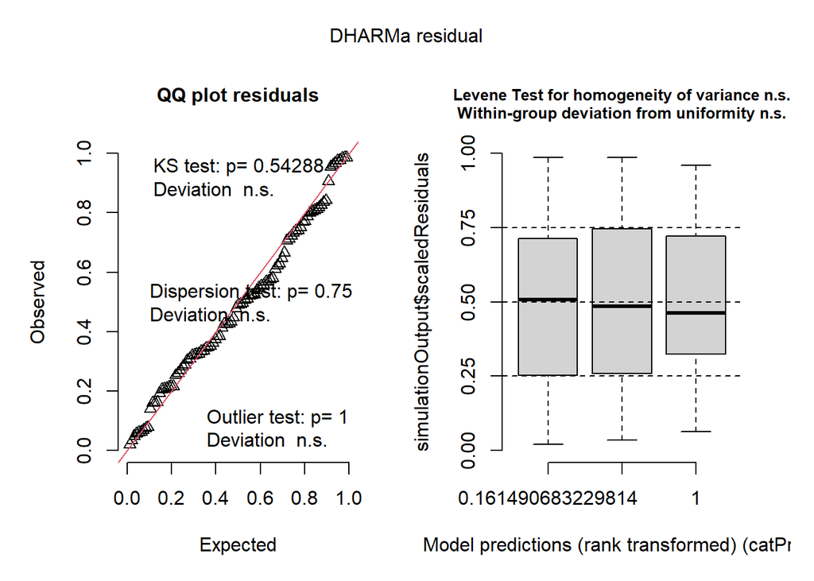

```r
# Species only model
simulationOutput <- simulateResiduals(mod2, n = 1000)

plot(simulationOutput)
```

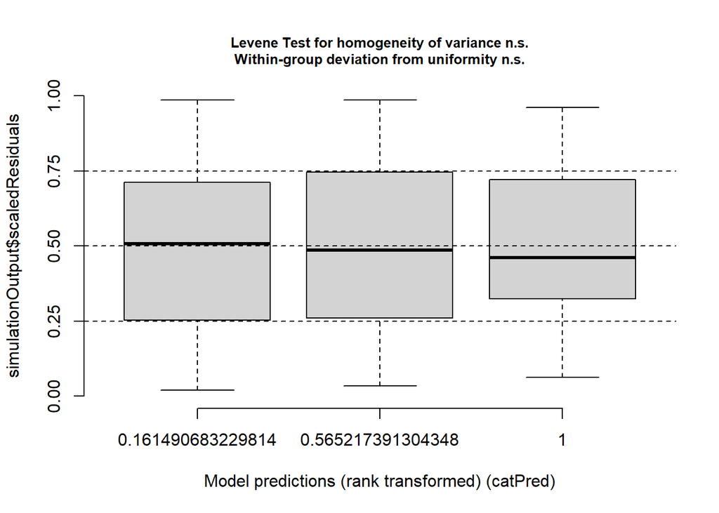

```r
plotResiduals(simulationOutput)
```

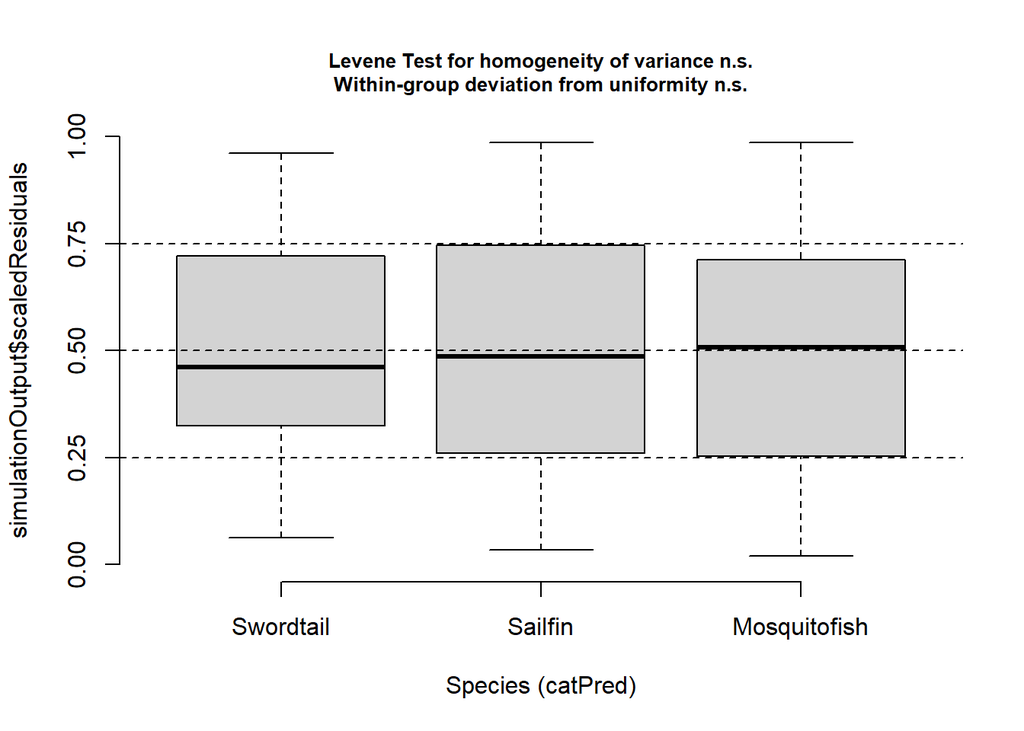

```r
plotResiduals(simulationOutput, form = rawTempData$Species)
```

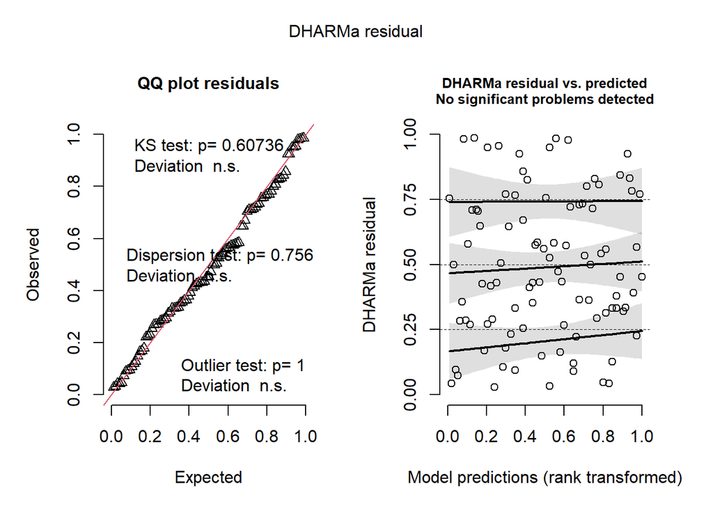

```r
  ### All good!


# Species and size model
simulationOutput2 <- simulateResiduals(mod2b, n = 1000)

plot(simulationOutput2)
```

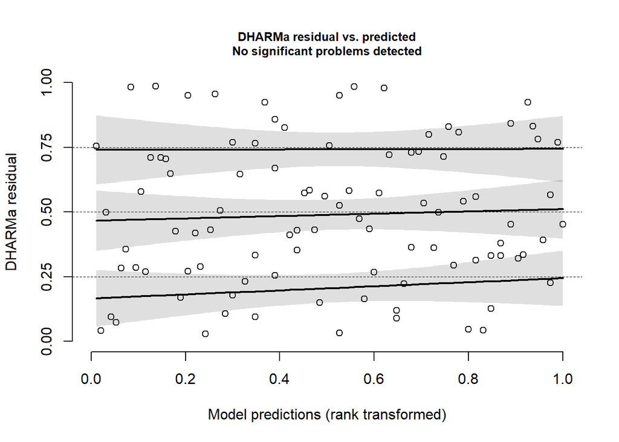

```r
plotResiduals(simulationOutput2)
```

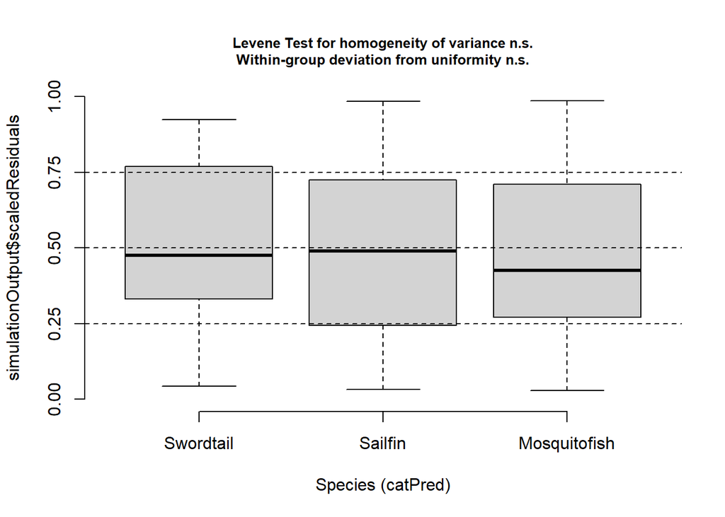

```r
plotResiduals(simulationOutput2, form = rawTempData$Species)
```

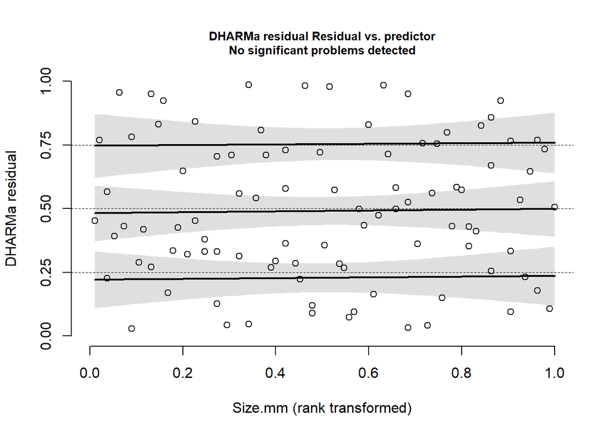

```r
plotResiduals(simulationOutput2, form = rawTempData$Size.mm)
```

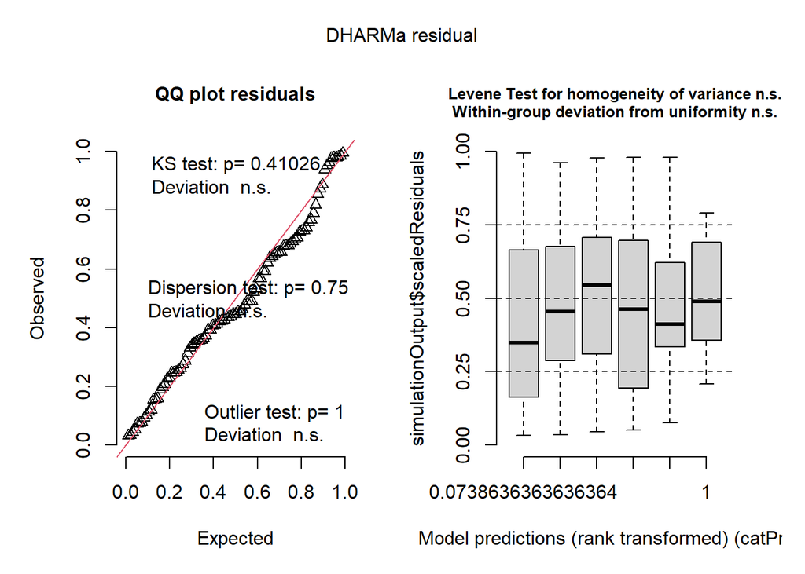

```r
  ### All good!

# Species and sex model
simulationOutput3 <- simulateResiduals(mod2c, n = 1000)

plot(simulationOutput3)
```

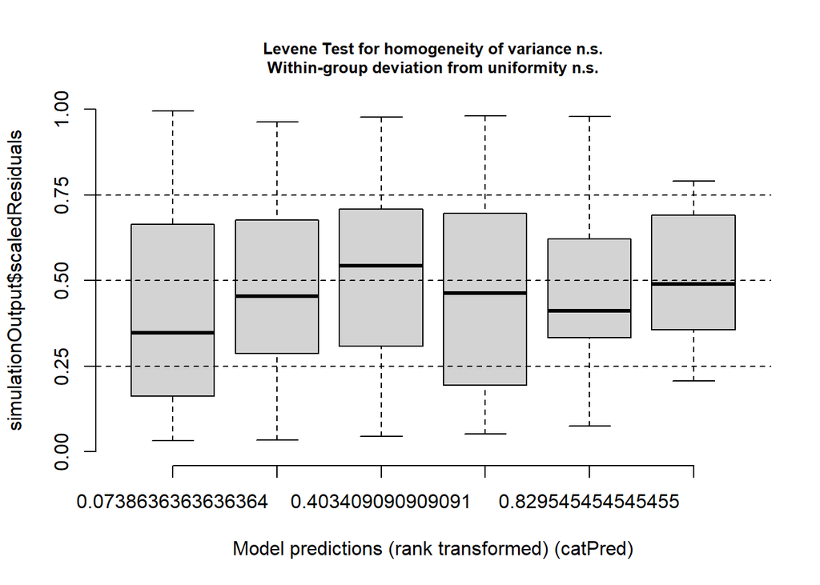

```r
plotResiduals(simulationOutput3)
```

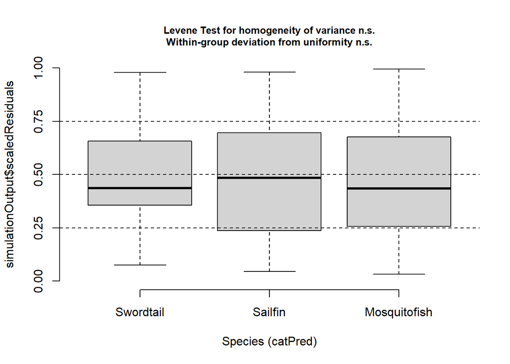

```r
plotResiduals(simulationOutput3, form = rawTempData$Species)
```

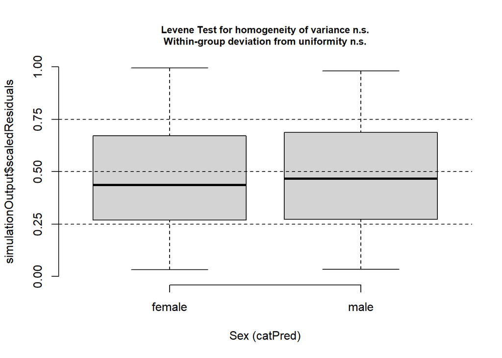

```r
plotResiduals(simulationOutput3, form = rawTempData$Sex)
```

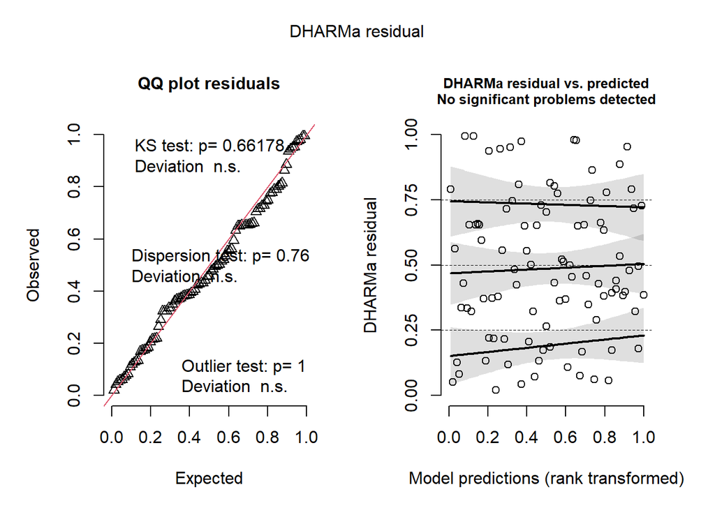

```r
  ### All good!

# Species and sex and size model
simulationOutput4 <- simulateResiduals(mod2d, n = 1000)

plot(simulationOutput4)
```